# PIT-IDS: Collider Bias

2025-09-01

We’re interested in estimating the impact of discrimination (referred to as **marginalized** or **marginalization** going forward) on educational outcomes (we could look at any number of different education-related outcomes; today, we’ll focus on high school graduation, **HSG**) in a city where low income neighborhoods carry a higher risk of exposure to environmental hazards than higher-income neighborhoods (**Poor_Nbhds**). We’ll focus specifically on the risk of exposure to lead, a toxin associated with cognitive and behavioral impairments, via chipped paint and lead-contaminated dust in older homes that may not have been properly maintained over the years.

We start by sketching a simple graphical model (a Directed Acyclic Graph or DAG) representing a hypothesized explanation of the ways in which **marginalization** impacts **HSG**. Each variable in the DAG is represented by a node, while an edge or arrow between two nodes indicates a causal relationship in the direction of the arrow.

This model proposes two pathways through which **marginalization** can shape **HSG**

- First, there is the direct pathway from **marginalization** to **HSG**,
- There is also an indirect pathway from *marginalization* to **HSG**, via **Poor_Nbhds**.

*Questions:*

1. Can you identify the direct and indirect pathways connecting **marginalization** to **HSG**?
2. In addition to the direct & indirect pathways connecting **marginalization** to **HSG**, there is one more causal pathway shown in this model. What is it? (i.e., *‘X has a direct/indirect impact Y’*)
3. Can you think of a plausible reason (or reasons) for the hypothesized relationships between **marginalization**, **Poor_Nbhds**, and **HSG** that are shown in the DAG below?
4. We know that not everyone experiences identical educational outcomes. Do you think this model does a good job of explaining why different people have different educational experiences (whether **HSG** or educational outcomes more broadly)?

[interactive chart not shown]

A more realistic DAG recognizes that factors *other than* discrimination may lead to living in poor neighborhoods. We’ll refer to these factors as vulnerabilities (**V**).

What are some possible examples of **V**?

Once included as a variable in the model, we notice that while **V** does influence **Poor_Nbhds**, it doesn’t *only* influence **Poor_Nbhds**. It may *also* influence **HSG**; to reflect this, we connect these variables with a causal edge. These Vulnerabilities are often difficult to observe, and thus difficult to identify in data, which we note using a dotted contour.

The updated DAG looks like this:

[interactive chart not shown]

Now, let’s say our data was restricted to a school district where the majority of students face poverty. In other words, if, in our data, **Poor_Nbhds** is a binary variable where 1 == “poor neighborhood” and 0 == “non-poor neighborhood”, **Poor_Nbhds** is fixed at 1 (and no longer a variable, as it doesn’t vary).

In this scenario, we are “selecting” on **Poor_Nbhds** (a collider), which opens up a non-causal pathway between **marginalization** and **HSG**.

The updated DAG looks like this:

[interactive chart not shown]

How does selection on a collider bias our estimates on the causal effect of discrimination on high school graduation?

To explore this question, we will simulate data that mirrors the relationships specified in our DAG. The data simulation also needs to make assumptions about the statistical characteristics of the data such as distributional forms and parameters. In reality, we would work with real data, make distributional assumption and estimate parameters under those assumptions. However, simulated data works well to illustrate collider bias as we can see how the “real” (simulated) parameters compare to those estimated when bias is present.

### Simulated data descriptive statistics

Let’s see what the data looks like. What do you notice when comparing all students vs. those living in poor neighborhood vs. those living in non-poor neighborhoods?

#### Full data

In this table, the mean values for **Marginalization** and **Poor_Nbhd** can be interpreted as ‘the probability that a student belongs to a marginalized group’ and ‘the probability that a student lives in a poor neighborhood’, respectively.

These probability statements can also be written as:

*P(Marginalization)* and

*P(Poor_Nbhd)*

| var | n_distinct | mean | min | max |
| --- | --- | --- | --- | --- |
| Marginalization | 2 | 0.2992 | 0 | 1 |
| Vulnerabilities | 10000 | -0.00485 | -4.03282 | 3.55658 |
| Poor_Nbhd | 2 | 0.402 | 0 | 1 |
| HSG | 10000 | 0.50549 | 0 | 1 |

#### Poor_Nbhd == 1

If we look only at the subset of students living in a *poor* neighborhood, the mean value of **Marginalization** can be interpreted as ‘the probability that a student belongs to a marginalized group, given that they live in a poor neighborhood’, or

*P(Marginalization|Poor_Nbhd == 1)*

| var | n_distinct | mean | min | max |
| --- | --- | --- | --- | --- |
| Marginalization | 2 | 0.37065 | 0 | 1 |
| Vulnerabilities | 4020 | 0.87859 | -1.44245 | 3.55658 |
| HSG | 4020 | 0.3347 | 0 | 0.54223 |

#### Poor_Nbhd == 0

And if we focus only on students living in *non-poor* neighborhoods, the mean value of **Marginalization** can be interpreted as ‘the probability that a student belongs to a marginalized group, given that they live in a non-poor neighborhood’, or

*P(Marginalization|Poor_Nbhd == 0)*

| var | n_distinct | mean | min | max |
| --- | --- | --- | --- | --- |
| Marginalization | 2 | 0.25117 | 0 | 1 |
| Vulnerabilities | 5980 | -0.59874 | -4.03282 | 1.61086 |
| HSG | 5980 | 0.6203 | 0.33618 | 1 |

### Correlations

Next let’s see how the variables in our simulated data are correlated with one another overall, and among the subset of student living in poor neighborhoods.

What is the correlation coefficient on **marginalization** and **vulnerabilities** in the full sample? Do they have a strong relationship?

What about when we restrict our data to students living in poor neighborhoods? What is the nature of the relationship between **marginalization** and **vulnerabilities** now?

#### Full sample

|  | Marginalization | Vulnerabilities | prob_poor | HSG |
| --- | --- | --- | --- | --- |
| Marginalization | 1 | 0.009 | 0.135 | -0.285 |
| Vulnerabilities | 0.009 | 1 | 0.856 | -0.905 |
| prob_poor | 0.135 | 0.856 | 1 | -0.891 |
| HSG | -0.285 | -0.905 | -0.891 | 1 |

#### Poor_Nbhd == 1

|  | Marginalization | Vulnerabilities | prob_poor | HSG |
| --- | --- | --- | --- | --- |
| Marginalization | 1 | -0.236 | -0.28 | -0.321 |
| Vulnerabilities | -0.236 | 1 | 0.764 | -0.742 |
| prob_poor | -0.28 | 0.764 | 1 | -0.514 |
| HSG | -0.321 | -0.742 | -0.514 | 1 |

See how **marginalization** and **vulnerabilities** are NOT correlated in the entire sample, but for the data on students in poor neighborhoods only, **marginalization** and **vulnerabilities** appear to be negatively correlated.

This is a product of selecting on a collider and leads to bias in our estimation of causal effects of **marginalization** on high school graduation.

### Estimating the effect of marginalization on High school graduation under collider bias.

#### Model 1

We first estimate parameters in linear regressions for all data (poor and non-poor neighborhoods) to see if we can recover the causal effect estimates of **marginalization** on **HSG**.

```r
# Estimate parameters in linear regressions for all data (poor and non-poor neighborhoods) to see if we can recover the causal effect estimates of Marginalization on HSG
lm_full <- lm(HSG ~ Marginalization + Poor_Nbhd, data = df)                # Observational realistic model (V unobserved)
summary(lm_full)
```

```
##
## Call:
## lm(formula = HSG ~ Marginalization + Poor_Nbhd, data = df)
##
## Residuals:
##      Min       1Q   Median       3Q      Max
## -0.29525 -0.05239 -0.00125  0.04918  0.36395
##
## Coefficients:
##                   Estimate Std. Error t value Pr(>|t|)
## (Intercept)      0.4969932  0.0009377  530.02   <2e-16 ***
## Marginalization -0.0626916  0.0016810  -37.29   <2e-16 ***
## Poor_Nbhd.L     -0.1966494  0.0011101 -177.14   <2e-16 ***
## ---
## Signif. codes:  0 '***' 0.001 '**' 0.01 '*' 0.05 '.' 0.1 ' ' 1
##
## Residual standard error: 0.07634 on 9997 degrees of freedom
## Multiple R-squared:  0.778,  Adjusted R-squared:  0.778
## F-statistic: 1.752e+04 on 2 and 9997 DF,  p-value: < 2.2e-16
```

#### Model 2

Then we assume we only have data for students living in poor neighborhoods (selection on collider) and run the regression for this data.

```r
# Now assume we only have data for students living in poor neighborhoods (selection on collider) and run the regression for this data.
df_sel <- df %>% filter(Poor_Nbhd == "1")
lm_sel  <- lm(HSG ~ Marginalization, data = df_sel)                       # selected-only
summary(lm_sel)
```

```
##
## Call:
## lm(formula = HSG ~ Marginalization, data = df_sel)
##
## Residuals:
##       Min        1Q    Median        3Q       Max
## -0.302692 -0.044936  0.006984  0.049444  0.221835
##
## Coefficients:
##                  Estimate Std. Error t value Pr(>|t|)
## (Intercept)      0.353558   0.001440  245.53   <2e-16 ***
## Marginalization -0.050867   0.002365  -21.51   <2e-16 ***
## ---
## Signif. codes:  0 '***' 0.001 '**' 0.01 '*' 0.05 '.' 0.1 ' ' 1
##
## Residual standard error: 0.07243 on 4018 degrees of freedom
## Multiple R-squared:  0.1032, Adjusted R-squared:  0.103
## F-statistic: 462.5 on 1 and 4018 DF,  p-value: < 2.2e-16
```

#### Model 3

Finally assume we can observe Vulnerabilities (unfeasible in practice) so we are able to control for this confounder. This model should give better estimates of the causal effect of **marginalization** on **HSG**.

```r
# Finally assume we observed Vulnerabilities so we could control for this confounder
lm_full_v <- lm(HSG ~ Marginalization + Poor_Nbhd + Vulnerabilities, data = df)  # reference (unfeasible in practice)

summary(lm_full_v)
```

```
##
## Call:
## lm(formula = HSG ~ Marginalization + Poor_Nbhd + Vulnerabilities,
##     data = df)
##
## Residuals:
##       Min        1Q    Median        3Q       Max
## -0.128316 -0.022084 -0.000299  0.021852  0.139707
##
## Coefficients:
##                   Estimate Std. Error t value Pr(>|t|)
## (Intercept)      0.5173499  0.0004130  1252.7   <2e-16 ***
## Marginalization -0.0818396  0.0007256  -112.8   <2e-16 ***
## Poor_Nbhd.L     -0.0875025  0.0007026  -124.5   <2e-16 ***
## Vulnerabilities -0.1029353  0.0004879  -211.0   <2e-16 ***
## ---
## Signif. codes:  0 '***' 0.001 '**' 0.01 '*' 0.05 '.' 0.1 ' ' 1
##
## Residual standard error: 0.03269 on 9996 degrees of freedom
## Multiple R-squared:  0.9593, Adjusted R-squared:  0.9593
## F-statistic: 7.851e+04 on 3 and 9996 DF,  p-value: < 2.2e-16
```

#### Compare models

We see, in fact, that this negative effect is the strongest in the model with all variables including vulnerabilities and the smallest when collider bias is present.

This is an example of how, even when we have population data (meaning data from all students in a school district), our estimates may carry bias.

| model | term | estimate | std.error | statistic | p.value |
| --- | --- | --- | --- | --- | --- |
| Full (no V) | (Intercept) | 0.497 | 0.0009 | 530.025 | 0 |
| Full (no V) | Marginalization | -0.0627 | 0.0017 | -37.2942 | 0 |
| Full (no V) | Poor_Nbhd.L | -0.1966 | 0.0011 | -177.1436 | 0 |
| Selected (Poor==1) | (Intercept) | 0.3536 | 0.0014 | 245.5322 | 0 |
| Selected (Poor==1) | Marginalization | -0.0509 | 0.0024 | -21.5061 | 0 |
| Full (with V) | (Intercept) | 0.5173 | 0.0004 | 1252.6745 | 0 |
| Full (with V) | Marginalization | -0.0818 | 0.0007 | -112.7891 | 0 |
| Full (with V) | Poor_Nbhd.L | -0.0875 | 0.0007 | -124.5401 | 0 |
| Full (with V) | Vulnerabilities | -0.1029 | 0.0005 | -210.979 | 0 |

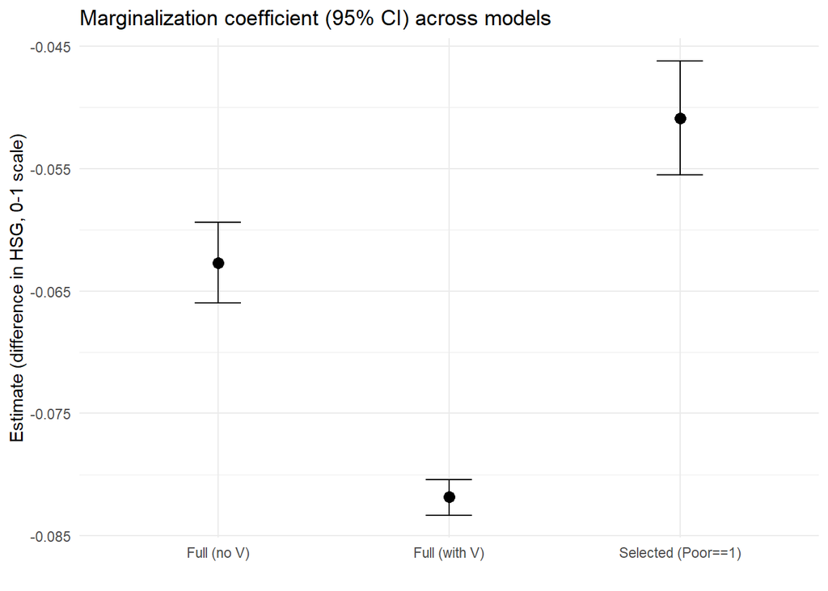

### Some real-world examples of collider bias

A salient example of collider bias was featured in a study that used police records (selected sample) to estimate the effects of segregation on use of force by police and erroneously found minimal effects. https://jmummolo.scholar.princeton.edu/publications/bias-built-how-administrative-records-mask-racially-biased-policing

Look for other cases of collider bias in public health and social welfare to become familiar with this type of bias and its potential impact on social policy. https://pmc.ncbi.nlm.nih.gov/articles/PMC6452862/